# Module 5 worksheet

```r
library(ggplot2) #load ggplot
library(ggthemes) #load themes package for ggplot
theme_set(theme_tufte()) # a theme I like.

#set some options that I like
theme_update(plot.title = element_text(hjust = 0.5),
             axis.line.x = element_line(color="black", size = 1),
             axis.line.y = element_line(color="black", size = 1),
             text=element_text(size=20),
             axis.text=element_text(size=15)) #center all titles and and axis lines
```

## # Exercise 7A

## Fit a count model

Dodd and Silvertown [1999](https://doi.org/10.1086/303238) explored the relationships between size , age, competition, on the number of cones produced by fir (*Abies balsamea*). Interestingly, some of these populations experience wave-like die offs that lead to bands of dead trees in the forest (see image [here](https://www.conifers.org/pi/ab/balsamea13.jpg)). These waves are thought to be driven by chronic wind-stress. Today we will explore how fir fecundity is related to tree size, and population that have and not had wave die-offs.

```r
fir.dat <- read.csv(file="../Data/Firs.csv")
head(fir.dat)
```

|  | DBH | fecundity | pop |
| --- | --- | --- | --- |
| 1 | 9.4 | 19 | nonwave |
| 2 | 10.6 | 42 | nonwave |
| 3 | 7.7 | 40 | nonwave |
| 4 | 10.6 | 68 | nonwave |
| 5 | 8.7 | 5 | nonwave |
| 6 | 8.1 | 21 | nonwave |

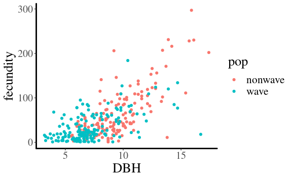

```r
ggplot(data=fir.dat, aes(x=DBH, y=fecundity, col=pop)) +
  geom_point()
```

2. Now fit a Poisson regression to `fecundity` using `pop` and `DBH` as predictor variables. Report model estimates and confidence intervals, and plot the model fits using the function `plot_model`.

```r
firs.pois <- glm(fecundity ~ DBH + pop, data=fir.dat, family=poisson)
confint(firs.pois)
```

```
                 2.5 %     97.5 %
(Intercept)  2.1822428  2.3063209
DBH          0.1881529  0.1990285
popwave     -0.2768167 -0.2071084
```

```r
summary(firs.pois)
```

```
Call:
glm(formula = fecundity ~ DBH + pop, family = poisson, data = fir.dat)

Deviance Residuals:
    Min       1Q   Median       3Q      Max
-15.976   -3.848   -1.107    2.602   15.382

Coefficients:
             Estimate Std. Error z value Pr(>|z|)
(Intercept)  2.244299   0.031653   70.90   <2e-16 ***
DBH          0.193600   0.002774   69.78   <2e-16 ***
popwave     -0.241915   0.017783  -13.60   <2e-16 ***
---
Signif. codes:  0 ‘***’ 0.001 ‘**’ 0.01 ‘*’ 0.05 ‘.’ 0.1 ‘ ’ 1

(Dispersion parameter for poisson family taken to be 1)

    Null deviance: 12145.1  on 310  degrees of freedom
Residual deviance:  6150.3  on 308  degrees of freedom
  (22 observations deleted due to missingness)
AIC: 7784.3

Number of Fisher Scoring iterations: 5
```

### Look, everything is supersignficant! This means we are either great scientists or our model has some problems. Guess which one…

# Exercise 7B

## Negative binomial regression

Repeat the analysis in 7A but use a negative binomial model. Use AIC to determine which fit is better. Do the parameter estimates or confidence intervals differ much between the results in 7A and 7B?

```r
library(MASS)
library(MuMIn)
firs.nb <- glm.nb(fecundity ~ DBH + pop, data=fir.dat)
summary(firs.nb)
```

```
Call:
glm.nb(formula = fecundity ~ DBH + pop, data = fir.dat, init.theta = 1.879220248,
    link = log)

Deviance Residuals:
    Min       1Q   Median       3Q      Max
-2.9538  -0.8534  -0.2319   0.4292   2.5591

Coefficients:
            Estimate Std. Error z value Pr(>|z|)
(Intercept)  2.06961    0.18202  11.370   <2e-16 ***
DBH          0.20851    0.01793  11.631   <2e-16 ***
popwave     -0.15599    0.09443  -1.652   0.0985 .
---
Signif. codes:  0 ‘***’ 0.001 ‘**’ 0.01 ‘*’ 0.05 ‘.’ 0.1 ‘ ’ 1

(Dispersion parameter for Negative Binomial(1.8792) family taken to be 1)

    Null deviance: 548.25  on 310  degrees of freedom
Residual deviance: 340.21  on 308  degrees of freedom
  (22 observations deleted due to missingness)
AIC: 2893.1

Number of Fisher Scoring iterations: 1

              Theta:  1.879
          Std. Err.:  0.153

 2 x log-likelihood:  -2885.149
```

```r
confint(firs.nb)
```

```
                 2.5 %     97.5 %
(Intercept)  1.6965998 2.44159848
DBH          0.1723803 0.24551541
popwave     -0.3452734 0.03326009
```

```r
model.sel(list(firs.nb, firs.pois))
```

```
Model selection table
  (Intrc)    DBH pop       family  class init.theta link df    logLik   AICc
1   2.070 0.2085   + NB(1.8792,l) negbin       1.88  log  4 -1442.575 2893.3
2   2.244 0.1936   +         p(l)    glm                  3 -3889.175 7784.4
    delta weight
1    0.00      1
2 4891.15      0
Abbreviations:
family: NB(1.8792,l) = ‘Negative Binomial(1.8792,log)’,
        p(l) = ‘poisson(log)’
Models ranked by AICc(x)
```

# Exercise 7C

## Modeling categorical data

Let’s look at the silversword data from the lecture.

1. Load the dataset `silversword.csv`.
2. Build a survival model using the predictors `Pop_size`, `Precip`, `Elev`, and `veg_cover`.
3. Increases in which predictors are associated with increases in survival? How about decreases in survival? Is there evidence of density dependence in the survival rate?

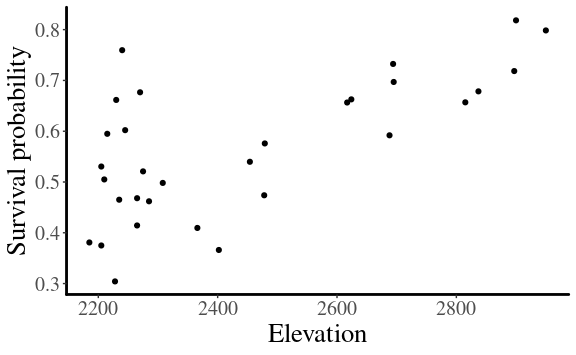

```r
silver.dat <- read.csv(file="../Data/Silversword.csv")
ggplot(data=silver.dat) +
  geom_point(mapping=aes(x=Elev, y=Survive/Pop_size)) + xlab("Elevation") + ylab("Survival probability")
```

```r
full.mod <- glm(cbind(Survive, Die) ~ Elev + Precip + veg_cover + Pop_size, family=binomial, data=silver.dat)
library(car)
vif(full.mod)
```

```
     Elev    Precip veg_cover  Pop_size
 1.537664  1.593304  1.334574  1.237206
```

```r
summary(full.mod)
```

```
Call:
glm(formula = cbind(Survive, Die) ~ Elev + Precip + veg_cover +
    Pop_size, family = binomial, data = silver.dat)

Deviance Residuals:
    Min       1Q   Median       3Q      Max
-9.4947  -2.3129   0.6574   2.1850   6.8991

Coefficients:
              Estimate Std. Error z value Pr(>|z|)
(Intercept) -3.863e+00  3.037e-01 -12.720  < 2e-16 ***
Elev         1.770e-03  7.605e-05  23.276  < 2e-16 ***
Precip      -4.067e-04  1.377e-04  -2.953  0.00315 **
veg_cover    8.946e-02  5.062e-03  17.675  < 2e-16 ***
Pop_size    -5.309e-06  5.848e-06  -0.908  0.36390
---
Signif. codes:  0 ‘***’ 0.001 ‘**’ 0.01 ‘*’ 0.05 ‘.’ 0.1 ‘ ’ 1

(Dispersion parameter for binomial family taken to be 1)

    Null deviance: 2074.36  on 30  degrees of freedom
Residual deviance:  397.58  on 26  degrees of freedom
AIC: 614.08

Number of Fisher Scoring iterations: 4
```

# Exercise 7D

## Fit an overdispersed categorical model

1. Use the `VGAM` package to fit the model you used above to fit the same mean function as in 7C but using a betabinomial model.
2. Compare the AIC values between the two model and compare their parameter estimates, are there systematic differences in the estimates?

```r
summary(model.bb)
```

```
Call:
vglm(formula = cbind(Survive, Die) ~ Elev + Precip + veg_cover +
    Pop_size, family = betabinomial, data = silver.dat)

Pearson residuals:
                   Min      1Q  Median     3Q   Max
logitlink(mu)  -2.5452 -0.5955  0.1528 0.7853 1.434
logitlink(rho) -0.7082 -0.6089 -0.3297 0.2104 4.155

Coefficients:
                Estimate Std. Error z value Pr(>|z|)
(Intercept):1 -3.707e+00  1.143e+00  -3.244  0.00118 **
(Intercept):2 -3.884e+00  2.807e-01 -13.840  < 2e-16 ***
Elev           1.577e-03  2.687e-04   5.869 4.39e-09 ***
Precip        -1.222e-04  5.992e-04  -0.204  0.83836
veg_cover      7.835e-02  1.633e-02   4.799 1.60e-06 ***
Pop_size      -9.828e-06  4.246e-05  -0.231  0.81695
---
Signif. codes:  0 ‘***’ 0.001 ‘**’ 0.01 ‘*’ 0.05 ‘.’ 0.1 ‘ ’ 1

Names of linear predictors: logitlink(mu), logitlink(rho)

Log-likelihood: -158.3473 on 56 degrees of freedom

Number of Fisher scoring iterations: 6

No Hauck-Donner effect found in any of the estimates
```